# Aeolian processes

Dr. Ahmad Redaa

2025-04-20

# Aeolian Processes

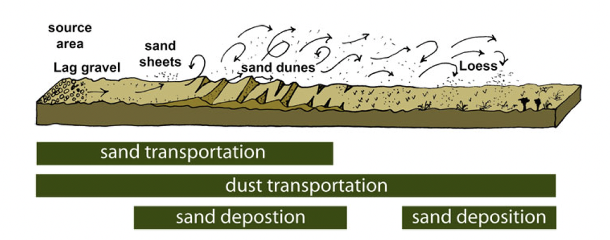

Sediment transport by wind. Source: [Steven, E. (2015)](https://openlibrary-repo.ecampusontario.ca/jspui/handle/123456789/402)

- Aeolian (or Eolian) processes refer to **wind-driven** geological activities.
- Wind plays a key role in **erosion, transport, and deposition** of sediments.
- Common in **deserts, coastal areas, glacial outwash plains, and drylands**.

# Erosion by Wind

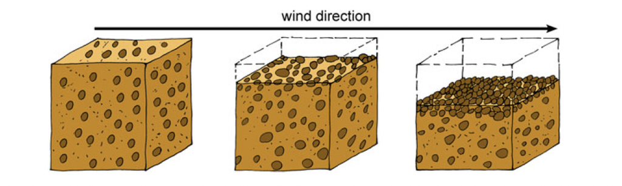

Desert pavement. Fine-grained material is removed by wind, leaving a concentration of larger particles that form desert pavement. Source: [Steven, E. (2015)](https://openlibrary-repo.ecampusontario.ca/jspui/handle/123456789/402)

## Deflation

- The removal of fine-grained particles, leaving a surface of coarser grains.
- Forms **desert pavements**.

## Abrasion

- Sandblasting of rock surfaces by wind.
- Creates **polished, scratched, and sculpted surfaces**.

## Attrition

- Windborne particles collide, wearing each other down.
- Produces **rounded grains**.

# Sediment Transport by Wind

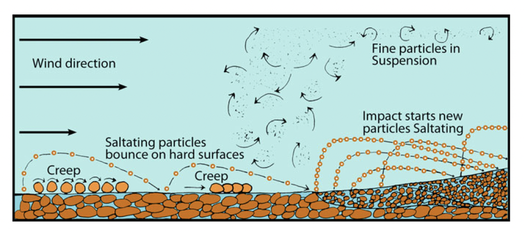

The process of sediment transport. The deposited particles (of sand, silt, and clay size) are entrained in by one of the four processes (Creep, Lift, Saltation, and Impact transport). When a particle rolls or slides across the surface, it is called Creep (Roiling). Lift is when a particle rises off the surface due to the Bernoulli effect. If the flow is turbulent, larger particles are trajected by a process known as Saltation. Impact transport occurs when one particle strikes another causing the second one to move ahead. Source: [Steven, E. (2015)](https://openlibrary-repo.ecampusontario.ca/jspui/handle/123456789/402)

## **Suspension**

- Fine dust particles are lifted and carried long distances.

## **Saltation**

- Medium-sized grains bounce along the ground.

## **Creep**

- Larger particles roll or slide across the surface.

## **Impact Transport**

- Grains collide, dislodging other particles.

# Erosional Landforms Formed by Wind

## **Desert Pavement**

- A surface of coarse particles left behind after deflation.

## **Rock Pedestal (Mushroom Rock)**

- Wind erodes the base more than the top, forming a **mushroom shape**.

## **Zeugen**

- Parallel ridges of alternating hard and soft rock eroded by wind.

## **Yardang**

- Narrow ridges sculpted by strong winds, aligned with prevailing wind direction.

## **Mesas and Buttes**

- Flat-topped highlands eroded over time; **buttes** are smaller remnants of mesas.

## **Inselberg**

- Isolated steep-sided rock hill that resists erosion.

## **Ventifacts**

- Rocks shaped and polished by wind-driven sand.

# **How Wind Deposits Sediments**

- Wind deposits sediments when its **velocity decreases**, causing particles to settle.
- This occurs due to **obstacles, changes in wind speed, or moisture content**.
- The deposited sediments form **dunes, sand sheets, loess deposits, and dust layers**.

# **Types of Wind Deposits**

## **1. Sand Dunes**

- **Definition:** Mounds or ridges of sand formed by wind deposition.
- **Formation:**
  - Wind slows down behind obstacles, causing sand to settle.
  - Sand accumulates and migrates over time.

## **2. Sand Sheets**

- **Definition:** Large, flat deposits of sand without significant dune formation.
- **Formation:**
  - Occur in regions with **low wind energy**, where sand settles evenly.
  - Often found near dune fields.

## **3. Loess Deposits**

- **Definition:** Fine-grained windblown dust (silt and clay) accumulating over time.
- **Formation:**
  - Wind transports **silt and clay** over long distances.
  - Dust settles when wind slows down.
  - Loess deposits contribute to **fertile soils**.
- **Examples:**
  - **Loess Plateau, China**
  - **Midwestern USA**
  - **Europe (Germany, Hungary, Ukraine)**

## **4. Windblown Dust (Dust Storm Deposits)**

- **Definition:** Fine sediments carried high into the atmosphere and deposited far from their source.
- **Formation:**
  - Strong winds lift **silt and clay** into suspension.
  - When wind speed drops, dust settles.
  - Can contribute to soil formation **far from the original source**.
- **Example:** Sahara dust reaching the **Amazon Rainforest**, enriching its soil.

## **5. Volcanic Ash Deposits**

- **Definition:** Wind-transported volcanic ash after explosive eruptions.
- **Formation:**
  - Ash is ejected into the atmosphere and carried by wind.
  - Settles over large areas, forming thick deposits.

# **Factors Controlling Wind Deposition**

1. **Wind Speed** – Faster winds transport particles farther; slower winds cause deposition.
2. **Particle Size** – **Larger grains settle quickly**; finer dust and silt travel longer distances.
3. **Topography** – Mountains, vegetation, and structures act as wind barriers.
4. **Moisture** – Humidity makes dust particles stick together, aiding deposition.

# Depositional Landforms Formed by Wind

Aeolian processes not only erode and transport materials but also lead to various depositional landforms when wind velocity decreases. These landforms vary in scale and complexity, from vast sand seas to microscopic dust deposits.

Depositional Landforms include: - Sand Seas (Ergs) - Sand Sheets - Ripples - Windblown Dust - Loess - Dust in Ocean Sediments - Volcanic Ash - Dunes and types: - Barchan - Dome - Barchanoid - Transverse - Seif - Parabolic - Longitudinal - Star - Reversing

# Sand Seas (Ergs)

- Definition: Vast regions of wind-blown sand, typically forming large dune fields.
- Extent: Usually >100,000 km²; found between 20–40° latitude in dry, subsiding trade wind belts.
- Features:
  - Composed of large dunes.
  - Found in deserts of North/South Africa, Asia, and Australia.
- Examples: Rub’ al Khali (Saudi Arabia), Sahara Desert, Martian polar regions.

# Sand Sheets

- Definition: Flat or gently undulating plains of sand, formed by successive deposition of wind-blown materials.
- Characteristics:
  - Lacks prominent dunes.
  - Often have a thin grass cover.
  - Deposits include sand from migrating ripples and wind-suspended dust.
- Example: Selima Sand Sheet, Eastern Sahara.

# Ripples

- Definition: Small-scale, wavelike ridges formed by the saltation of sand grains.
- Scale: Centimeters to meters in wavelength.
- Formation:
  - Created by wind pushing grains in short jumps (saltation).
  - Typically aligned perpendicular to wind direction.

# Windblown Dust

- Composition: Fine-grained particles of silt and clay size.
- Transport:
  - Can travel long distances in suspension.
  - Forms dust storms under strong winds.
- Significance:
  - Adds fertility to soils.
  - Affects climate and visibility.

# Loess

- Definition: Thick accumulations of wind-deposited silt.
- Composition: Primarily silt-sized particles, high porosity (~60%).
- Origin: Often derived from glacial outwash plains.
- Distribution:
  - China: Loess Plateau (Huangtu Plateau).
  - USA: Palouse region, Midwest, and Mississippi River Valley.

# Dust in Ocean Sediments

- Process: Fine particles carried by wind and deposited into oceans.
- Significance:
  - Contributes to abyssal clay and pelagic sedimentation.
  - Reflects continental climatic conditions.

# Volcanic Ash (Tephra)

- Definition: Fine volcanic particles ejected during eruptions and transported by wind.
- Behavior:
  - If erupted high enough, can be suspended for days or weeks.
  - Eventually settles as widespread deposits. -Impact:
  - Affects air travel, climate, and landscape development.

# Dunes

Dunes are mounds or ridges of sand formed when wind velocity drops and sand is deposited. They are asymmetrical with a gentle windward slope and a steeper leeward slipface.

## Factors Influencing Dune Shape

- Sand supply
- Wind speed and direction
- Vegetation
- Surface roughness

# Types of Sand Dunes

| **Type** | **Shape / Features** | **Wind Conditions** | **Sand Supply** | **Typical Environment** |
| --- | --- | --- | --- | --- |
| **Barchan** | Crescent-shaped with horns pointing downwind; single slipface | Unidirectional | Limited | Desert floors |
| **Dome** | Circular or elliptical mounds; no slipface | Variable or light winds | Limited | Transition zones |
| **Barchanoid** | Linked barchans forming wavy ridges | Steady unidirectional | Moderate to abundant | Between barchans and transverse |
| **Transverse** | Long ridges perpendicular to wind direction; single slipface | Constant, moderate | Abundant | Sand-rich deserts |
| **Seif** | Long, narrow, sinuous ridges parallel to prevailing wind | Bidirectional or shifting | Moderate | Desert interiors |
| **Parabolic** | U-shaped; horns point upwind; stabilized by vegetation | Constant coastal winds | Moderate to abundant | Coastal or semi-arid with vegetation |
| **Longitudinal** | Long, straight/sinuous ridges aligned with average wind direction; dual slipfaces | Bidirectional or converging wind fronts | Moderate | Arid deserts |
| **Star** | Star or pyramid shape with arms radiating from a central peak; multiple slipfaces | Multidirectional | Abundant | Large dune fields |
| **Reversing** | Hybrid between star and transverse; two slipfaces | Alternating | Variable | Transitional environments |

# Major Types of Sand Dunes

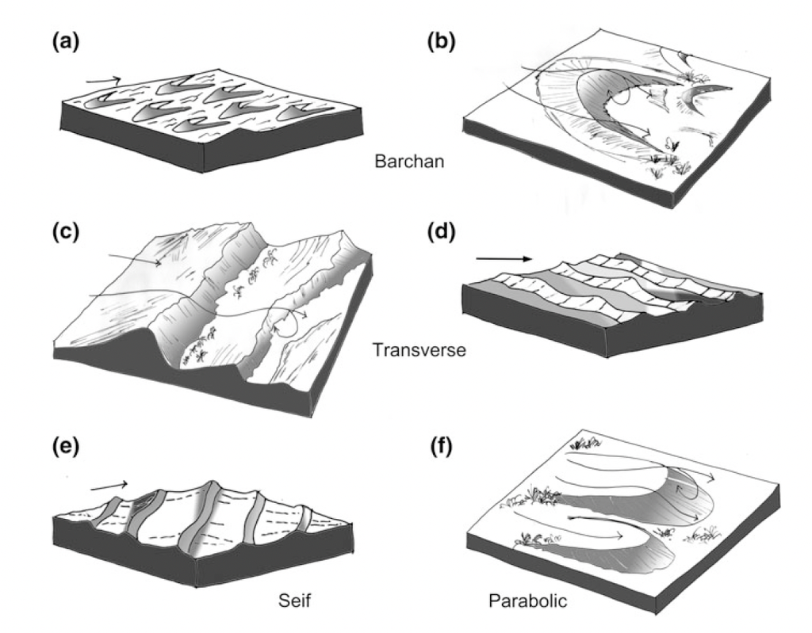

Major types of sand dunes. **a**–**b** Barchan dunes form in areas that have a limited amount of sand, a nearly constant wind direction, and a generally flat, dry surface with little vegetation. The tips of barchan dunes point downwind. **c**–**d** Transverse dunes form long ridges of sand that are perpendicular to the prevailing wind direction in areas of little or no vegetation and abundant sand. **e** Seif dunes (also called Longitudinal dunes) form long, parallel ridges of sand aligned roughly parallel to the prevailing wind direction. They typically form where sand supplies are limited. **f** Parabolic dunes typically form in coastal areas that have a partial cover of vegetation, a strong onshore wind, and abundant sand. Source: [Steven, E. (2015)](https://openlibrary-repo.ecampusontario.ca/jspui/handle/123456789/402)

# Deserts and Desert Types

Deserts are **arid regions** where **average annual precipitation is less than 250 mm** and **evaporation exceeds precipitation**. These landscapes are shaped by dryness, sparse vegetation, and active surface processes like wind erosion and flash floods.

Deserts are dynamic in size and distribution and can form under a variety of climatic and geographic settings. Their classification is based on the origin of aridity and geographical context.

## 1. Subtropical Deserts (Trade Wind Deserts)

- **Location**: 20°–30° N and S latitude, under the descending limb of the Hadley Cell.
- **Climate**: Hot, dry air; clear skies; intense solar heating.
- **Formation**:
  - Descending air warms adiabatically, increasing moisture capacity and preventing condensation.
- **Examples**:
  - **Sahara Desert** (North Africa)
  - **Kalahari Desert** (Southern Africa)
  - **Great Australian Desert**

## 2. Continental Deserts

- **Location**: Deep within continents, far from moisture sources.
- **Climate**: Hot summers, cold winters; low humidity.
- **Formation**:
  - Moisture is lost as air masses travel inland.
  - Limited precipitation due to continentality effect.
- **Examples**:
  - **Gobi Desert** (China and Mongolia)
  - **Taklamakan Desert** (Xinjiang, China)

## 3. Rainshadow Deserts

- **Location**: Leeward side of mountain ranges.
- **Climate**: Arid due to orographic precipitation on windward side.
- **Formation**:
  - Moist air rises on mountain slopes → cools and rains → dry air descends on the other side.
- **Examples**:
  - **Sonoran Desert** (Arizona, USA)
  - **Patagonian Desert** (Argentina)

## 4. Coastal Deserts

- **Location**: Western coasts of continents near 20°–30° latitude.
- **Climate**: Cool, dry air; frequent fog; minimal rainfall.
- **Formation**:
  - Cold ocean currents cool the air above, reducing its ability to hold moisture.
- **Examples**:
  - **Atacama Desert** (Chile – driest on Earth)
  - **Namib Desert** (Namibia)

## 5. Polar Deserts

- **Location**: High-latitude regions (>60° N/S)
- **Climate**: Very cold; precipitation <250 mm, mostly snow; long, harsh winters.
- **Formation**:
  - Cold, dry air limits moisture content and precipitation.
  - Ground often permanently frozen (permafrost).
- **Examples**:
  - **Antarctica**
  - **Northern Greenland**

## 6. Monsoon Deserts

- **Location**: Regions influenced by seasonal monsoon patterns.
- **Climate**: Wet-dry seasonal contrast.
- **Formation**:
  - Rain-shadow effects during monsoon cycles create dry zones on leeward sides.
- **Examples**:
  - **Thar Desert** (India and Pakistan)
  - Receives sporadic rainfall mainly during short monsoon bursts.

## 7. Paleodeserts

- **Definition**: Ancient deserts formed under previous climatic regimes, now inactive.
- **Evidence**:
  - Fossil dunes, relict sand seas, and sedimentary records in current non-arid areas.
- **Examples**:
  - **Nebraska Sand Hills** (USA) – now stabilized by vegetation, once an active dune field.
  - Fossil desert deposits up to 500 Ma old have been found globally.

## 8. Extraterrestrial Deserts

- **Location**: Found on other planets and moons.
- **Conditions**:
  - Lack of atmosphere or moisture, extreme temperature swings.
- **Examples**:
  - **Mars**: Hosts sand dunes and circumpolar sand seas with aeolian features.
  - **Titan** (Saturn’s moon): Shows evidence of large dunes composed of organic particles.

# Surface Processes and Desert Landforms

Desert landscapes are shaped by a combination of **wind, water, physical weathering**, and **lack of vegetation**. These regions exhibit distinct landforms formed through both **erosional and depositional** processes. The dominance of mechanical weathering, sparse rainfall, and ephemeral stream activity leads to unique geomorphological features.

## 1. Weathering and Mass Wasting

- **Dominated by mechanical (physical) weathering** due to:
  - Limited moisture
  - Intense temperature fluctuations
  - Sparse vegetation
- **Processes include**:
  - Rockfalls
  - Rockslides
  - Debris accumulation
- **Chemical weathering is minimal** due to low humidity.
- **Landscapes are often bare rock with coarse debris.**

## 2. Fluvial Landforms in Deserts

Though deserts are defined by aridity, **ephemeral streams** and **flash floods** can cause significant landscape modifications. Water erosion forms landforms that often reflect **infrequent but intense** rainfall events.

### 2.1 Playa Lakes (Dry Lakes)

- **Definition**: Flat-bottomed depressions that **temporarily fill with water** during rare rainfall events.
- **Formation**: Water collects in internal drainage basins and evaporates, leaving **salts and minerals (evaporites)**.
- **Appearance**: Often white due to salt crusts.
- **Other names**: Sabkhas, Salinas.
- **Common in**: Arid basins and intermontane valleys.

### 2.2 Alluvial Fans and Bajadas

#### Alluvial Fans

- **Fan-shaped deposits** of sediment formed where a stream exits a mountain range onto a flat plain.
- **Velocity drop** causes sediment to be deposited.
- **Coarse debris** near the source; finer material outward.

#### Bajadas

- **Coalesced alluvial fans** along mountain fronts.
- Create **gently sloping surfaces** that transition from upland to basin.

### 2.3 Pediments

- **Gently sloping erosional surfaces** at the base of retreating mountains.
- Formed by **long-term fluvial erosion** and **sheet wash**.
- Expose **bedrock** and are not depositional features.
- Represent a **mature erosional stage** of the desert landscape.

### 2.4 Inselbergs

- **Isolated hills or mountains** rising abruptly from a flat erosional plain.
- Composed of **resistant rock** (granite, gneiss).
- Result from **differential erosion**—less resistant material erodes away.
- **Examples**: Uluru (Australia), Bornhardts in Africa.

## 3. Desertification

- **Definition**: The process by which fertile land becomes desert.
- **Causes**:
  - **Climate change**: Alterations in atmospheric/oceanic circulation.
  - **Human activity**: Overgrazing, deforestation, groundwater depletion, poor land management.
- **Impacts**:
  - Loss of arable land
  - Increased dust storms
  - Migration and food insecurity
- **Reversible?** In some cases, **restoration** is possible through reforestation, conservation, and water management.

# Aridity

**Aridity** refers to the state of having very little precipitation, resulting in dry climates with limited vegetation and low soil moisture. It is a defining characteristic of desert regions and plays a crucial role in shaping surface processes and landforms.

## 1. Classification of Arid Zones

Arid zones are classified based on **annual precipitation** and **temperature**. These classifications help geologists understand climatic regimes and predict geomorphic processes.

### 1.1 Based on Precipitation

| **Zone Type** | **Annual Precipitation (mm)** | **Vegetation Cover** |
| --- | --- | --- |
| **Semiarid** | 250–500 | Steppe, savannah, or grassland |
| **Arid** | 50–250 | Sparse shrubs or desert grasses |
| **Extremely Arid** | <50 | Nearly barren |
| **Polar** | Very low snowfall | Frozen desert conditions |

### 1.2 Based on Temperature

| **Temperature Zone** | **Description** |
| --- | --- |
| **Hot** | Persistent high temperatures year-round |
| **Mild/Cool** | Moderate seasonal variation |
| **Cold** | Cold winters, cool summers |
| **Polar** | Sub-freezing conditions year-round |

## 2. Global Distribution of Arid Zones

Arid zones are found on **all continents** and in **all climatic belts**, but they are most concentrated:

- **Between 10°–35° N and S latitude** (subtropical dry zones)
- **In continental interiors**
- **In rainshadow areas behind mountain ranges**
- **Along western continental margins** where cold ocean currents prevail

### Notable Examples

| **Continent** | **Major Arid Zones** |
| --- | --- |
| **Africa** | Sahara, Kalahari, Namib |
| **Asia** | Gobi, Taklamakan, Thar |
| **Australia** | Great Victoria, Simpson, Great Sandy |
| **North America** | Sonoran, Mojave, Great Basin |
| **South America** | Atacama, Patagonian |
| **Polar Regions** | Antarctica, Northern Greenland |

## 3. Causes of Aridity

Multiple factors contribute to aridity. These may act independently or in combination.

### 3.1 Atmospheric High Pressure

- **Mechanism**: Descending air in the subtropical high-pressure belt (Hadley Cell) warms, increasing its moisture-holding capacity.
- **Effect**: Suppresses cloud formation and precipitation.
- **Location**: Between 15°–30° N and S of the Equator.
- **Examples**: Sahara, Arabian Desert, Great Australian Desert.

### 3.2 Rainshadow Effect

- **Mechanism**: Mountains force moist air to rise, cool, and precipitate on the windward side. The leeward side receives dry air.
- **Effect**: Creates deserts behind mountain ranges.
- **Examples**: Sonoran Desert (USA), Patagonian Desert (Argentina).

### 3.3 Cold Ocean Currents

- **Mechanism**: Cold currents cool air above, lowering its moisture capacity.
- **Effect**: Limits rainfall even near coastal regions.
- **Examples**: Atacama Desert (Humboldt Current), Namib Desert (Benguela Current).

### 3.4 Continentality

- **Mechanism**: Inland locations far from oceans have limited access to moisture-laden winds.
- **Effect**: Progressive drying of air masses leads to minimal precipitation.
- **Examples**: Gobi Desert, Central Australian deserts.

# Further reading

Chapter 13 in the book Fundamentals of Physical Geology by S. Jain (Springer India, 2014).